# WEEK 3 NYPD Shooting Incident Data Report

HDaher

2024-04-06

# Description

- Data set of every Shooting Incident in NYC since 2006 to end of previous calendar year.
- Each record includes information about the event, the location and time of occurrence.
- information related to suspect and victim demographics is also included.
- This data is manually extracted every quarter and reviewed by the Office of Management Analysis and Planning before being posted on the NYPD website.

```r
url_NYPD <- "https://data.cityofnewyork.us/api/views/833y-fsy8/rows.csv?accessType=DOWNLOAD"

NYPD <- read.csv(url_NYPD)
```

# Libraries

```r
library(dplyr)
library(lubridate)
```

```r
library(ggplot2)
library(broom)
```

# Data Exploration

```r
dim(NYPD)
```

```
## [1] 28562    21
```

```r
tail(NYPD)
```

```
##       INCIDENT_KEY OCCUR_DATE OCCUR_TIME      BORO LOC_OF_OCCUR_DESC PRECINCT
## 28557    270719378 07/02/2023   21:40:00     BRONX           OUTSIDE       46
## 28558    265354835 03/19/2023   23:48:00     BRONX            INSIDE       47
## 28559    272968931 08/16/2023   02:46:00     BRONX           OUTSIDE       41
## 28560    270489846 06/27/2023   12:27:00     BRONX            INSIDE       41
## 28561    271021661 07/08/2023   11:27:00    QUEENS           OUTSIDE      102
## 28562    271818283 07/24/2023   23:38:00 MANHATTAN           OUTSIDE       28
##       JURISDICTION_CODE LOC_CLASSFCTN_DESC             LOCATION_DESC
## 28557                 0             STREET                    (null)
## 28558                 0         COMMERCIAL            GROCERY/BODEGA
## 28559                 0             STREET                    (null)
## 28560                 0           DWELLING   MULTI DWELL - APT BUILD
## 28561                 0             STREET         BEAUTY/NAIL SALON
## 28562                 2            HOUSING MULTI DWELL - PUBLIC HOUS
##       STATISTICAL_MURDER_FLAG PERP_AGE_GROUP PERP_SEX      PERP_RACE
```

[output cut: 20 more lines]

```r
#numerical statistics summary
summary(NYPD[, sapply(NYPD, is.numeric)])
```

```
##   INCIDENT_KEY          PRECINCT     JURISDICTION_CODE   X_COORD_CD
##  Min.   :  9953245   Min.   :  1.0   Min.   :0.0000    Min.   : 914928
##  1st Qu.: 65439914   1st Qu.: 44.0   1st Qu.:0.0000    1st Qu.:1000068
##  Median : 92711254   Median : 67.0   Median :0.0000    Median :1007772
##  Mean   :127405824   Mean   : 65.5   Mean   :0.3219    Mean   :1009424
##  3rd Qu.:203131993   3rd Qu.: 81.0   3rd Qu.:0.0000    3rd Qu.:1016807
##  Max.   :279758069   Max.   :123.0   Max.   :2.0000    Max.   :1066815
##                                      NA's   :2
##    Y_COORD_CD        Latitude       Longitude
##  Min.   :125757   Min.   :40.51   Min.   :-74.25
##  1st Qu.:182912   1st Qu.:40.67   1st Qu.:-73.94
##  Median :194901   Median :40.70   Median :-73.92
##  Mean   :208380   Mean   :40.74   Mean   :-73.91
##  3rd Qu.:239814   3rd Qu.:40.82   3rd Qu.:-73.88
##  Max.   :271128   Max.   :40.91   Max.   :-73.70
##                   NA's   :59      NA's   :59
```

```r
#categorical statistics summary
summary(NYPD[, sapply(NYPD, is.factor)])
```

```
## < table of extent 0 x 0 >
```

```r
# Looking at column values
glimpse(NYPD)
```

```
## Rows: 28,562
## Columns: 21
## $ INCIDENT_KEY            <int> 244608249, 247542571, 84967535, 202853370, 270…
## $ OCCUR_DATE              <chr> "05/05/2022", "07/04/2022", "05/27/2012", "09/…
## $ OCCUR_TIME              <chr> "00:10:00", "22:20:00", "19:35:00", "21:00:00"…
## $ BORO                    <chr> "MANHATTAN", "BRONX", "QUEENS", "BRONX", "BROO…
## $ LOC_OF_OCCUR_DESC       <chr> "INSIDE", "OUTSIDE", "", "", "", "", "", "", "…
## $ PRECINCT                <int> 14, 48, 103, 42, 83, 23, 113, 77, 48, 49, 73, …
## $ JURISDICTION_CODE       <int> 0, 0, 0, 0, 0, 2, 0, 0, 0, 0, 0, 0, 0, 0, 0, 0…
## $ LOC_CLASSFCTN_DESC      <chr> "COMMERCIAL", "STREET", "", "", "", "", "", ""…
## $ LOCATION_DESC           <chr> "VIDEO STORE", "(null)", "", "", "", "MULTI DW…
## $ STATISTICAL_MURDER_FLAG <chr> "true", "true", "false", "false", "false", "fa…
## $ PERP_AGE_GROUP          <chr> "25-44", "(null)", "", "25-44", "25-44", "", "…
## $ PERP_SEX                <chr> "M", "(null)", "", "M", "M", "", "", "", "", "…
## $ PERP_RACE               <chr> "BLACK", "(null)", "", "UNKNOWN", "BLACK", "",…
## $ VIC_AGE_GROUP           <chr> "25-44", "18-24", "18-24", "25-44", "25-44", "…
## $ VIC_SEX                 <chr> "M", "M", "M", "M", "M", "M", "M", "M", "M", "…
## $ VIC_RACE                <chr> "BLACK", "BLACK", "BLACK", "BLACK", "BLACK", "…
## $ X_COORD_CD              <dbl> 986050, 1016802, 1048632, 1014493, 1009149, 99…
## $ Y_COORD_CD              <dbl> 214231.0, 250581.0, 198262.0, 242565.0, 190104…
## $ Latitude                <dbl> 40.75469, 40.85440, 40.71063, 40.83242, 40.688…
## $ Longitude               <dbl> -73.99350, -73.88233, -73.76777, -73.89071, -7…
## $ Lon_Lat                 <chr> "POINT (-73.9935 40.754692)", "POINT (-73.8823…
```

```r
names(NYPD)
```

```
##  [1] "INCIDENT_KEY"            "OCCUR_DATE"
##  [3] "OCCUR_TIME"              "BORO"
##  [5] "LOC_OF_OCCUR_DESC"       "PRECINCT"
##  [7] "JURISDICTION_CODE"       "LOC_CLASSFCTN_DESC"
##  [9] "LOCATION_DESC"           "STATISTICAL_MURDER_FLAG"
## [11] "PERP_AGE_GROUP"          "PERP_SEX"
## [13] "PERP_RACE"               "VIC_AGE_GROUP"
## [15] "VIC_SEX"                 "VIC_RACE"
## [17] "X_COORD_CD"              "Y_COORD_CD"
## [19] "Latitude"                "Longitude"
## [21] "Lon_Lat"
```

# Data Preparation

```r
# Convert categorical variables to factors
NYPD <- NYPD %>%
  mutate_at(vars(BORO, PERP_SEX, PERP_RACE, VIC_AGE_GROUP, VIC_SEX, VIC_RACE), factor)
# Remove unnecessary columns
NYPD <- NYPD %>% select(-Lon_Lat)

summary(NYPD)
```

```
##   INCIDENT_KEY        OCCUR_DATE         OCCUR_TIME
##  Min.   :  9953245   Length:28562       Length:28562
##  1st Qu.: 65439914   Class :character   Class :character
##  Median : 92711254   Mode  :character   Mode  :character
##  Mean   :127405824
##  3rd Qu.:203131993
##  Max.   :279758069
##
##             BORO       LOC_OF_OCCUR_DESC     PRECINCT     JURISDICTION_CODE
##  BRONX        : 8376   Length:28562       Min.   :  1.0   Min.   :0.0000
##  BROOKLYN     :11346   Class :character   1st Qu.: 44.0   1st Qu.:0.0000
##  MANHATTAN    : 3762   Mode  :character   Median : 67.0   Median :0.0000
##  QUEENS       : 4271                      Mean   : 65.5   Mean   :0.3219
##  STATEN ISLAND:  807                      3rd Qu.: 81.0   3rd Qu.:0.0000
##                                           Max.   :123.0   Max.   :2.0000
##                                                           NA's   :2
##  LOC_CLASSFCTN_DESC LOCATION_DESC      STATISTICAL_MURDER_FLAG
##  Length:28562       Length:28562       Length:28562
##  Class :character   Class :character   Class :character
##  Mode  :character   Mode  :character   Mode  :character
##
##
##
##
##  PERP_AGE_GROUP       PERP_SEX              PERP_RACE     VIC_AGE_GROUP
##  Length:28562             : 9310   BLACK         :11903   <18    : 2954
##  Class :character   (null): 1141                 : 9310   1022   :    1
##  Mode  :character   F     :  444   WHITE HISPANIC: 2510   18-24  :10384
##                     M     :16168   UNKNOWN       : 1837   25-44  :12973
##                     U     : 1499   BLACK HISPANIC: 1392   45-64  : 1981
##                                    (null)        : 1141   65+    :  205
##                                    (Other)       :  469   UNKNOWN:   64
##  VIC_SEX                             VIC_RACE       X_COORD_CD
##  F: 2760   AMERICAN INDIAN/ALASKAN NATIVE:   11   Min.   : 914928
##  M:25790   ASIAN / PACIFIC ISLANDER      :  440   1st Qu.:1000068
##  U:   12   BLACK                         :20235   Median :1007772
##            BLACK HISPANIC                : 2795   Mean   :1009424
##            UNKNOWN                       :   70   3rd Qu.:1016807
##            WHITE                         :  728   Max.   :1066815
##            WHITE HISPANIC                : 4283
##    Y_COORD_CD        Latitude       Longitude
##  Min.   :125757   Min.   :40.51   Min.   :-74.25
##  1st Qu.:182912   1st Qu.:40.67   1st Qu.:-73.94
##  Median :194901   Median :40.70   Median :-73.92
##  Mean   :208380   Mean   :40.74   Mean   :-73.91
##  3rd Qu.:239814   3rd Qu.:40.82   3rd Qu.:-73.88
##  Max.   :271128   Max.   :40.91   Max.   :-73.70
##                   NA's   :59      NA's   :59
```

```r
sapply(NYPD, function(x) sum(is.na(x)))
```

```
##            INCIDENT_KEY              OCCUR_DATE              OCCUR_TIME
##                       0                       0                       0
##                    BORO       LOC_OF_OCCUR_DESC                PRECINCT
##                       0                       0                       0
##       JURISDICTION_CODE      LOC_CLASSFCTN_DESC           LOCATION_DESC
##                       2                       0                       0
## STATISTICAL_MURDER_FLAG          PERP_AGE_GROUP                PERP_SEX
##                       0                       0                       0
##               PERP_RACE           VIC_AGE_GROUP                 VIC_SEX
##                       0                       0                       0
##                VIC_RACE              X_COORD_CD              Y_COORD_CD
##                       0                       0                       0
##                Latitude               Longitude
##                      59                      59
```

```r
names(NYPD)
```

```
##  [1] "INCIDENT_KEY"            "OCCUR_DATE"
##  [3] "OCCUR_TIME"              "BORO"
##  [5] "LOC_OF_OCCUR_DESC"       "PRECINCT"
##  [7] "JURISDICTION_CODE"       "LOC_CLASSFCTN_DESC"
##  [9] "LOCATION_DESC"           "STATISTICAL_MURDER_FLAG"
## [11] "PERP_AGE_GROUP"          "PERP_SEX"
## [13] "PERP_RACE"               "VIC_AGE_GROUP"
## [15] "VIC_SEX"                 "VIC_RACE"
## [17] "X_COORD_CD"              "Y_COORD_CD"
## [19] "Latitude"                "Longitude"
```

# Exploring Incident Time Series Data

## Total Yearly Incidents

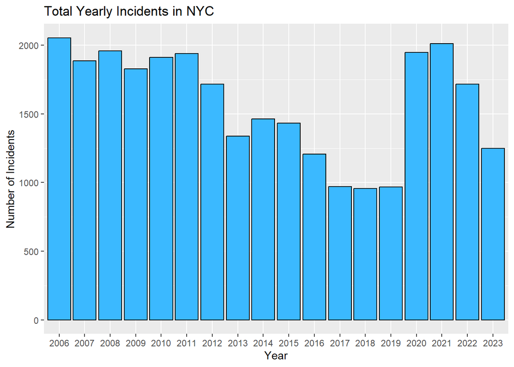

```r
# Change OCCUR_DATE to Date format
NYPD$OCCUR_DATE <- as.Date(NYPD$OCCUR_DATE, format = "%m/%d/%Y")

# Get year
NYPD$YEAR <- format(NYPD$OCCUR_DATE, "%Y")

# Group by year
yearly_incidents <- NYPD %>%
  group_by(YEAR) %>%
  summarise(Incidents = n())

# Plot total yearly incidents
g <- ggplot(yearly_incidents, aes(x = YEAR, y = Incidents)) +
  geom_col(fill = "#3BB9FF", colour = "black") +
  labs(title = "Total Yearly Incidents in NYC",
       x = "Year",
       y = "Number of Incidents") +
  theme(legend.position = "none")

# Print the plot
print(g)
```

## Total Daily Incidents

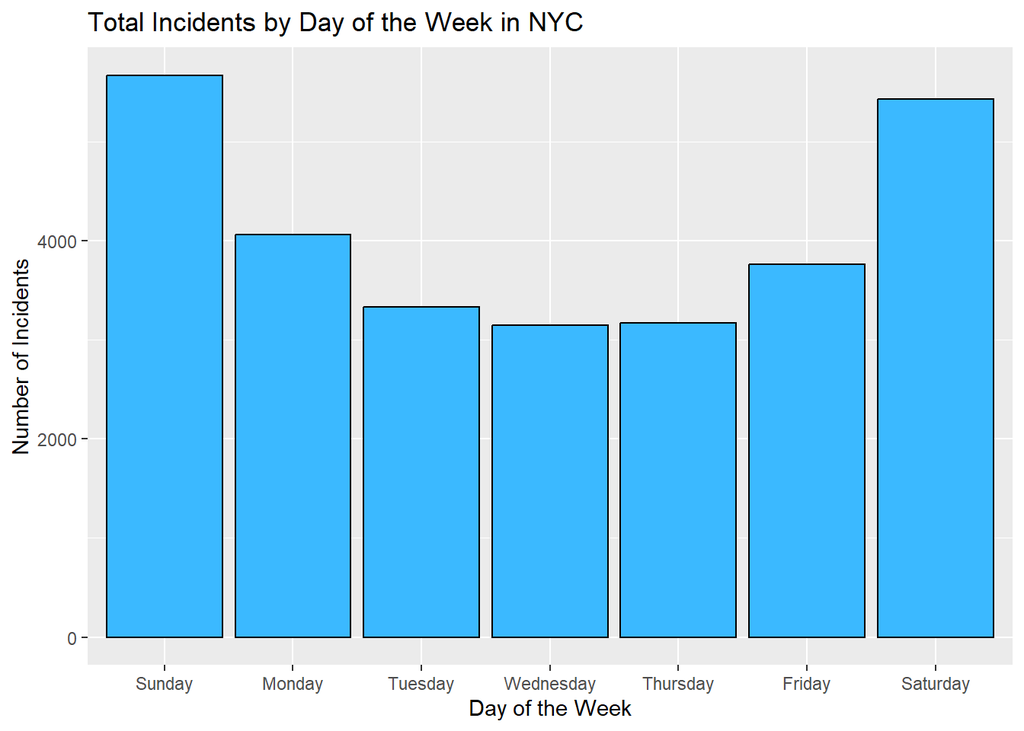

```r
# Get day
NYPD$DAY_OF_WEEK <- weekdays(NYPD$OCCUR_DATE)

# Group totals by day of week
daily_incidents <- NYPD %>%
  group_by(DAY_OF_WEEK) %>%
  summarise(Incidents = n())


order_days <- c("Sunday", "Monday", "Tuesday", "Wednesday", "Thursday", "Friday", "Saturday")

# Plot total daily incidents
g <- ggplot(daily_incidents, aes(x = factor(DAY_OF_WEEK, levels = order_days), y = Incidents)) +
  geom_col(fill = "#3BB9FF", color = "black") +
  labs(title = "Total Incidents by Day of the Week in NYC",
       x = "Day of the Week",
       y = "Number of Incidents") +
  theme(legend.position = "none")

# Print the plot
print(g)
```

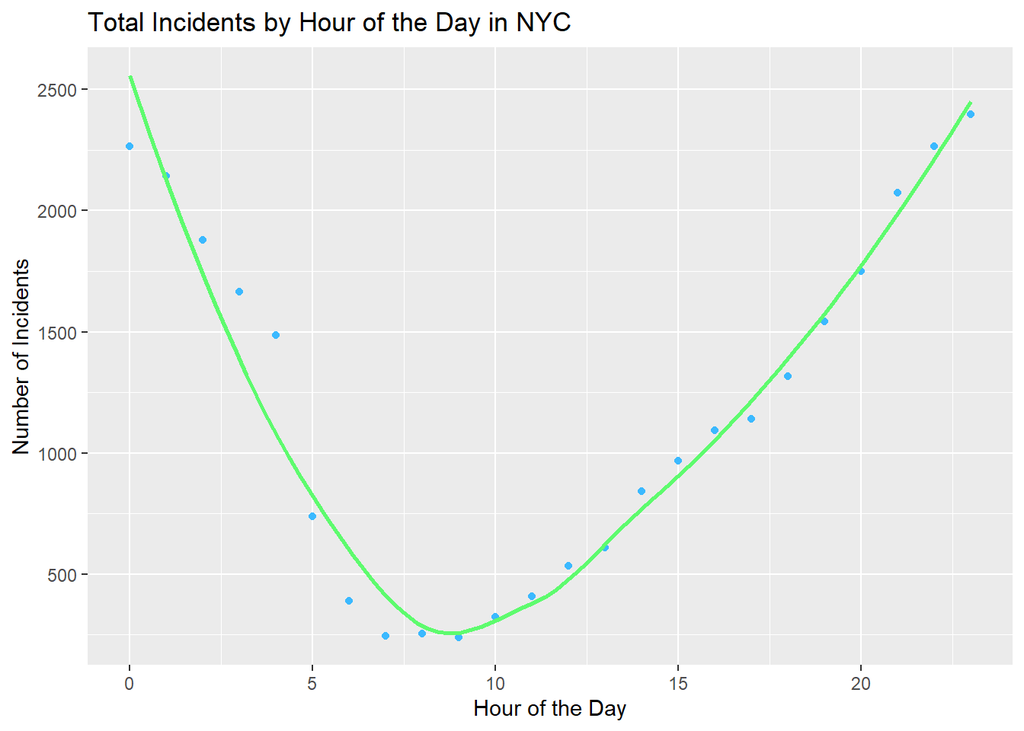

```r
# Extract hour of the day from OCCUR_TIME
NYPD$HOUR_OF_DAY <- as.numeric(format(strptime(NYPD$OCCUR_TIME, format = "%H:%M:%S"), "%H"))

# Group data by hour of the day and count the number of incidents
hourly_incidents <- NYPD %>%
  group_by(HOUR_OF_DAY) %>%
  summarise(Incidents = n())


# Plot total incidents vs hour of day
g <- ggplot(hourly_incidents, aes(x = HOUR_OF_DAY, y = Incidents)) +
  geom_point(color = "#3BB9FF") +
  geom_smooth(method = "loess", se = FALSE, color = "#5EFB6E") +
  labs(title = "Total Incidents by Hour of the Day in NYC",
       x = "Hour of the Day",
       y = "Number of Incidents")


print(g)
```

# Exploring Location Data

## Total Incidents by Borough

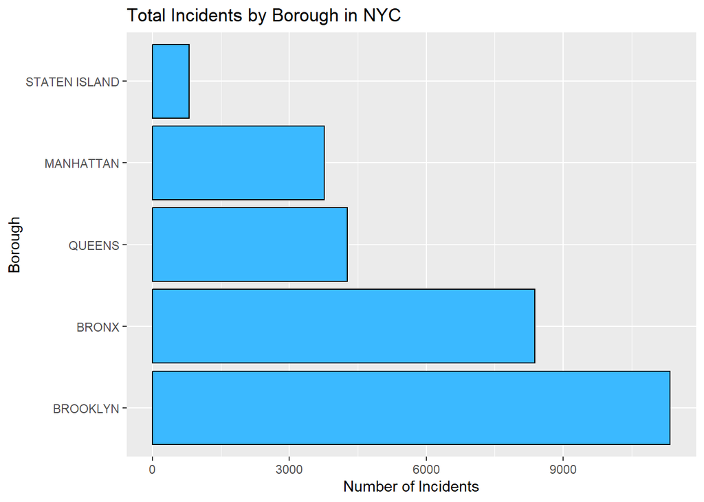

```r
# Group data by BORO
boro_incidents <- NYPD %>%
  group_by(BORO) %>%
  summarise(Incidents = n())

# Plot total incidents by BORO
g <- ggplot(boro_incidents, aes(x = reorder(BORO, -Incidents), y = Incidents)) +
  geom_bar(stat = "identity", fill = "#3BB9FF", color = "black") +
  labs(title = "Total Incidents by Borough in NYC",
       x = "Borough",
       y = "Number of Incidents") +
  coord_flip()


print(g)
```

## Total Incidents by Location Classification

```r
# Create a copy of the NYPD dataset
NYPD_copy <- NYPD

# Filter out blanks and NAs, then summarize incidents by location classification
classfctn_incidents <- NYPD_copy %>%
  filter(LOCATION_DESC != "", !is.na(LOCATION_DESC)) %>%
  group_by(LOCATION_DESC) %>%
  summarise(Incidents = n()) %>%
  arrange(desc(Incidents)) %>%
  top_n(10)  # Select top 10
```

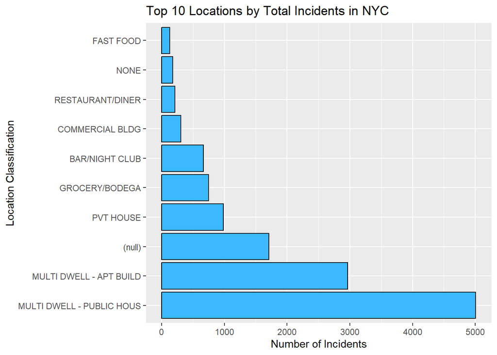

```r
# Plot total incidents for the top 10 location classifications
g <- ggplot(classfctn_incidents, aes(x = reorder(LOCATION_DESC, -Incidents), y = Incidents)) +
  geom_bar(stat = "identity", fill = "#3BB9FF", color = "black") +
  labs(title = "Top 10 Locations by Total Incidents in NYC ",
       x = "Location Classification",
       y = "Number of Incidents") +

  coord_flip()

# plot
print(g)
```

# Modeling Factors that can Contribute to the Fatality of a Shooting

```r
NYPD$STATISTICAL_MURDER_FLAG <- as.integer(NYPD$STATISTICAL_MURDER_FLAG == "true")

# Fit the model with all specified variables
glm.fit <- glm(STATISTICAL_MURDER_FLAG ~ PERP_RACE + PERP_SEX + PERP_AGE_GROUP +
               VIC_AGE_GROUP + VIC_SEX + VIC_RACE + BORO + HOUR_OF_DAY +
               DAY_OF_WEEK +
               LOC_CLASSFCTN_DESC + LOCATION_DESC + LOC_OF_OCCUR_DESC +
               PRECINCT, data = NYPD, family = binomial)


# Summary of the model
summary(glm.fit)
```

```
##
## Call:
## glm(formula = STATISTICAL_MURDER_FLAG ~ PERP_RACE + PERP_SEX +
##     PERP_AGE_GROUP + VIC_AGE_GROUP + VIC_SEX + VIC_RACE + BORO +
##     HOUR_OF_DAY + DAY_OF_WEEK + LOC_CLASSFCTN_DESC + LOCATION_DESC +
##     LOC_OF_OCCUR_DESC + PRECINCT, family = binomial, data = NYPD)
##
## Coefficients: (4 not defined because of singularities)
##                                           Estimate Std. Error z value Pr(>|z|)
## (Intercept)                             -1.382e+01  1.475e+02  -0.094 0.925312
## PERP_RACE(null)                         -2.053e-01  1.109e-01  -1.852 0.064088
## PERP_RACEAMERICAN INDIAN/ALASKAN NATIVE -1.076e+01  3.753e+02  -0.029 0.977120
## PERP_RACEASIAN / PACIFIC ISLANDER        2.163e+00  4.849e-01   4.462 8.13e-06
## PERP_RACEBLACK                           1.981e+00  4.506e-01   4.396 1.10e-05
## PERP_RACEBLACK HISPANIC                  1.939e+00  4.548e-01   4.263 2.01e-05
## PERP_RACEUNKNOWN                         1.342e+00  3.905e-01   3.437 0.000587
## PERP_RACEWHITE                           2.388e+00  4.717e-01   5.063 4.14e-07
## PERP_RACEWHITE HISPANIC                  2.139e+00  4.531e-01   4.721 2.34e-06
## PERP_SEX(null)                                  NA         NA      NA       NA
## PERP_SEXF                               -1.709e+00  2.876e-01  -5.941 2.83e-09
## PERP_SEXM                               -1.787e+00  2.646e-01  -6.752 1.46e-11
## PERP_SEXU                                       NA         NA      NA       NA
## PERP_AGE_GROUP(null)                            NA         NA      NA       NA
## PERP_AGE_GROUP<18                       -1.263e-01  4.394e-01  -0.288 0.773721
## PERP_AGE_GROUP1020                      -1.247e+01  5.354e+02  -0.023 0.981414
## PERP_AGE_GROUP1028                      -1.193e+01  5.354e+02  -0.022 0.982222
## PERP_AGE_GROUP18-24                     -2.990e-02  4.355e-01  -0.069 0.945275
## PERP_AGE_GROUP224                       -1.243e+01  5.354e+02  -0.023 0.981473
## PERP_AGE_GROUP25-44                      1.849e-01  4.357e-01   0.424 0.671328
## PERP_AGE_GROUP45-64                      4.787e-01  4.433e-01   1.080 0.280246
## PERP_AGE_GROUP65+                        2.470e-01  5.124e-01   0.482 0.629762
## PERP_AGE_GROUP940                       -1.290e+01  5.354e+02  -0.024 0.980782
## PERP_AGE_GROUPUNKNOWN                   -2.686e+00  4.054e-01  -6.626 3.46e-11
## VIC_AGE_GROUP1022                       -1.136e+01  5.354e+02  -0.021 0.983067
## VIC_AGE_GROUP18-24                       2.556e-01  6.275e-02   4.074 4.62e-05
## VIC_AGE_GROUP25-44                       5.090e-01  6.169e-02   8.251  < 2e-16
## VIC_AGE_GROUP45-64                       5.509e-01  7.985e-02   6.899 5.22e-12
## VIC_AGE_GROUP65+                         9.300e-01  1.685e-01   5.518 3.44e-08
## VIC_AGE_GROUPUNKNOWN                     4.567e-01  3.263e-01   1.400 0.161596
## VIC_SEXM                                 1.148e-01  5.284e-02   2.173 0.029743
```

[output cut: 169 more lines]

```
## LOCATION_DESCVARIETY STORE
## LOCATION_DESCVIDEO STORE                **
## LOC_OF_OCCUR_DESCINSIDE                 ***
## LOC_OF_OCCUR_DESCOUTSIDE
## PRECINCT
## ---
## Signif. codes:  0 '***' 0.001 '**' 0.01 '*' 0.05 '.' 0.1 ' ' 1
##
## (Dispersion parameter for binomial family taken to be 1)
##
##     Null deviance: 28061  on 28561  degrees of freedom
## Residual deviance: 26312  on 28464  degrees of freedom
## AIC: 26508
##
## Number of Fisher Scoring iterations: 12
```

```r
# Obtain tidy version of the glm model
tidy_glm <- tidy(glm.fit)

# Remove NA coefficients and sort the coefficients in descending order
sorted_tidy_glm <- tidy_glm %>%
  filter(!is.na(estimate)) %>%
  arrange(desc(estimate))

# Print the sorted table of coefficients
print(sorted_tidy_glm)
```

```
## # A tibble: 98 × 5
##    term                             estimate std.error statistic p.value
##    <chr>                               <dbl>     <dbl>     <dbl>   <dbl>
##  1 LOCATION_DESCCHECK CASH             14.9     535.      0.0279 0.978
##  2 LOCATION_DESCLOAN COMPANY           14.8     535.      0.0276 0.978
##  3 LOCATION_DESCSCHOOL                 13.9     535.      0.0260 0.979
##  4 VIC_RACEASIAN / PACIFIC ISLANDER    11.9     147.      0.0807 0.936
##  5 VIC_RACEWHITE HISPANIC              11.8     147.      0.0800 0.936
##  6 VIC_RACEWHITE                       11.8     147.      0.0799 0.936
##  7 VIC_RACEBLACK                       11.7     147.      0.0796 0.937
##  8 VIC_RACEBLACK HISPANIC              11.5     147.      0.0783 0.938
##  9 VIC_RACEUNKNOWN                     10.9     147.      0.0741 0.941
## 10 LOCATION_DESCVIDEO STORE             3.08      1.08    2.85   0.00439
## # ℹ 88 more rows
```

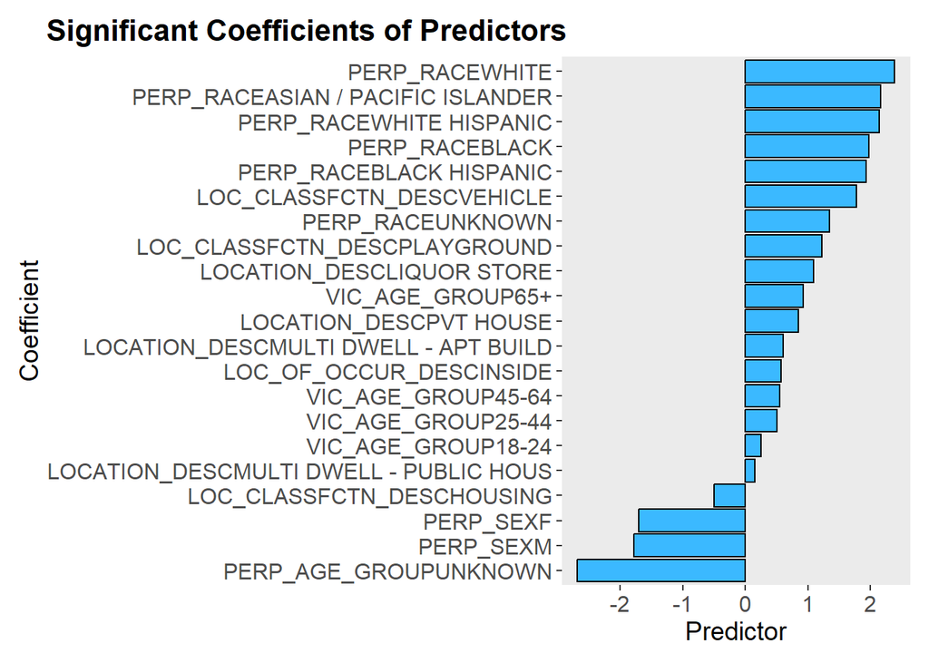

```r
tidy_glm <- tidy(glm.fit)

# Remove rows with NA coefficients, non-significant p-values, and the intercept
tidy_glm <- tidy_glm %>%
  filter(!is.na(estimate) & p.value < 0.001 & term != "(Intercept)")

# Create a plot
ggplot(tidy_glm, aes(x = reorder(term, estimate), y = estimate)) +
  geom_col(fill = "#3BB9FF", color = "black", show.legend = FALSE) +
  coord_flip() +
  labs(x = "Coefficient", y = "Predictor", title = "Significant Coefficients of Predictors") +
  theme(
    axis.text.x = element_text(size = 12),
    axis.text.y = element_text(size = 12),
    axis.title = element_text(size = 14),
    plot.title = element_text(size = 16, face = "bold", hjust = 3),  # Align title to the left properly
    panel.grid.major = element_blank(),  # Remove major grid lines
    panel.grid.minor = element_blank(),  # Remove minor grid lines
    plot.margin = margin(10, 10, 10, 10)  # Adjust plot margins if needed
  )
```

[output not shown]